# GLM Practice

j4yr0u93

11/25/2020

# 1.1

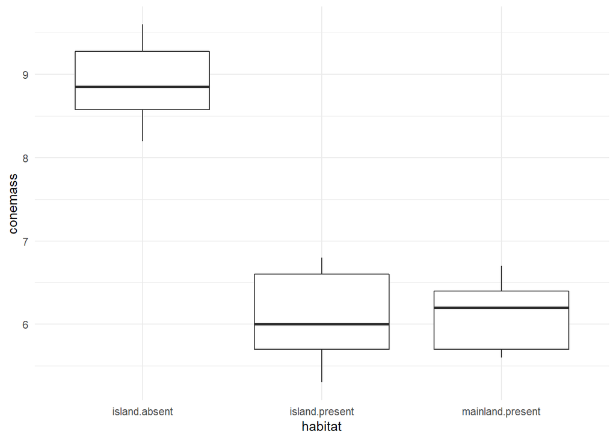

# 1.2

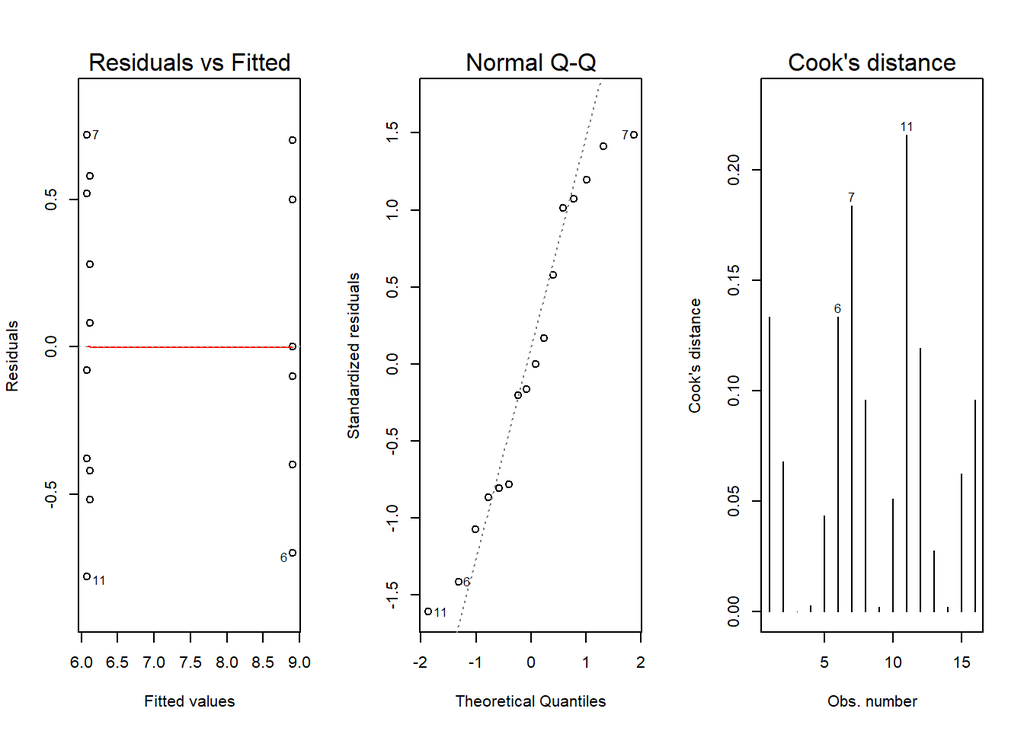

```
## Levene's Test for Homogeneity of Variance (center = median)
##       Df F value Pr(>F)
## group  2  0.2148 0.8095
##       13
```

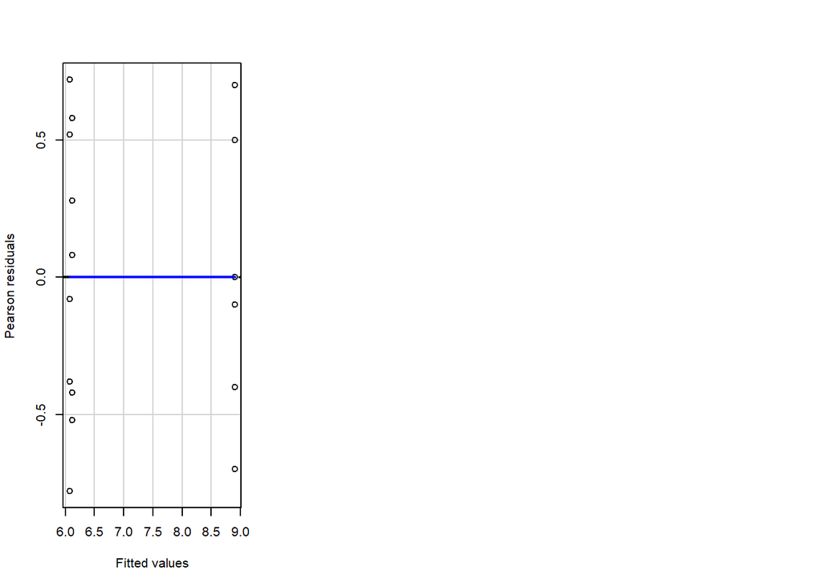

Residuals vs fitted, qq plots, and cook’s distance all look normal within acceptable range and linear.

# 1.3

```
## [1] 0.8851294
```

~89% of variance is explained by the independent variable.

# 1.4

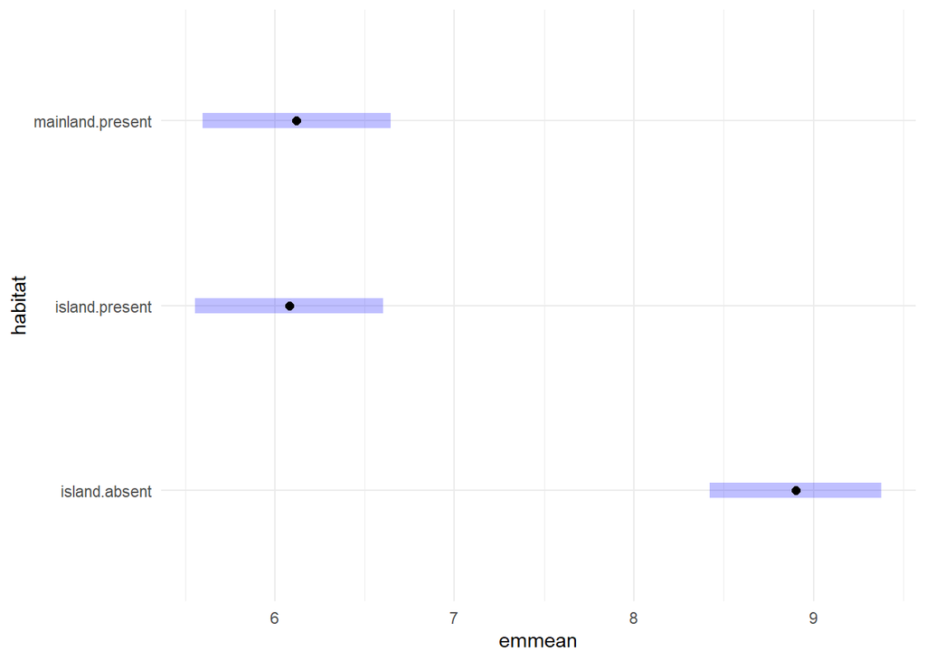

Island Absent in the outlier from the means, non-default correction not required.

# 2.1

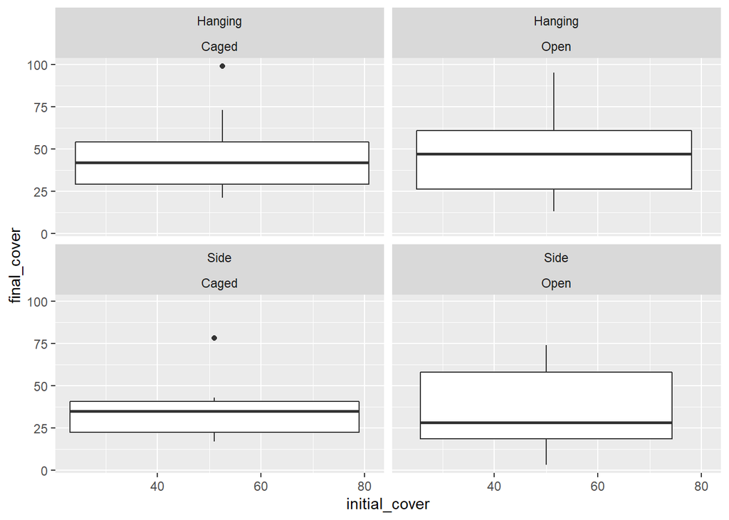

# 2.2

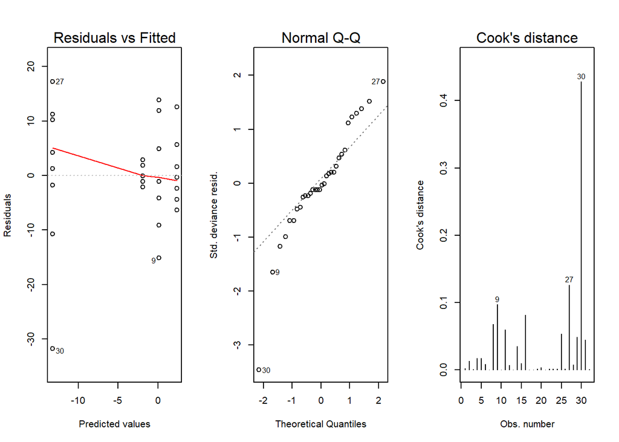

```
##
##  Shapiro-Wilk normality test
##
## data:  residuals(trans_glm)
## W = 0.91664, p-value = 0.01687
```

```
## Levene's Test for Homogeneity of Variance (center = median)
##       Df F value Pr(>F)
## group  3  2.7642 0.0605 .
##       28
## ---
## Signif. codes:  0 '***' 0.001 '**' 0.01 '*' 0.05 '.' 0.1 ' ' 1
```

# 2.3

```
##
##  Shapiro-Wilk normality test
##
## data:  residuals(trans_cov)
## W = 0.90022, p-value = 0.006273
```

```
##
##  Shapiro-Wilk normality test
##
## data:  residuals(trans_delta)
## W = 0.95055, p-value = 0.1494
```

```
##
##  Shapiro-Wilk normality test
##
## data:  residuals(trans_logit)
## W = 0.9097, p-value = 0.01104
```

```
## Levene's Test for Homogeneity of Variance (center = median)
##       Df F value  Pr(>F)
## group  3  2.7931 0.05869 .
##       28
## ---
## Signif. codes:  0 '***' 0.001 '**' 0.01 '*' 0.05 '.' 0.1 ' ' 1
```

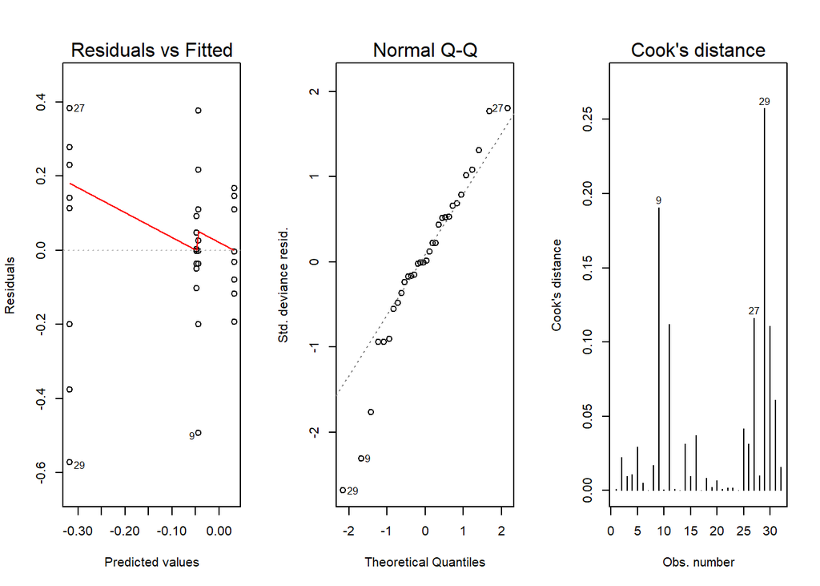

# 2.4

```
## Analysis of Deviance Table
##
## Model: gaussian, link: identity
##
## Response: change_in_cover/initial_cover
##
## Terms added sequentially (first to last)
##
##
##                         Df Deviance Resid. Df Resid. Dev
## NULL                                       31     2.0141
## caged                    1 0.239545        30     1.7745
## position_on_block        1 0.249345        29     1.5252
## caged:position_on_block  1 0.075217        28     1.4500
```

```
## NOTE: Results may be misleading due to involvement in interactions
```

```
##  contrast     estimate     SE  df z.ratio p.value
##  Caged - Open    0.173 0.0805 Inf 2.151   0.0315
##
## Results are averaged over the levels of: position_on_block
```

```
## NOTE: Results may be misleading due to involvement in interactions
```

```
##  contrast       estimate     SE  df z.ratio p.value
##  Hanging - Side    0.177 0.0805 Inf 2.194   0.0282
##
## Results are averaged over the levels of: caged
```

```
## NOTE: Results may be misleading due to involvement in interactions
```

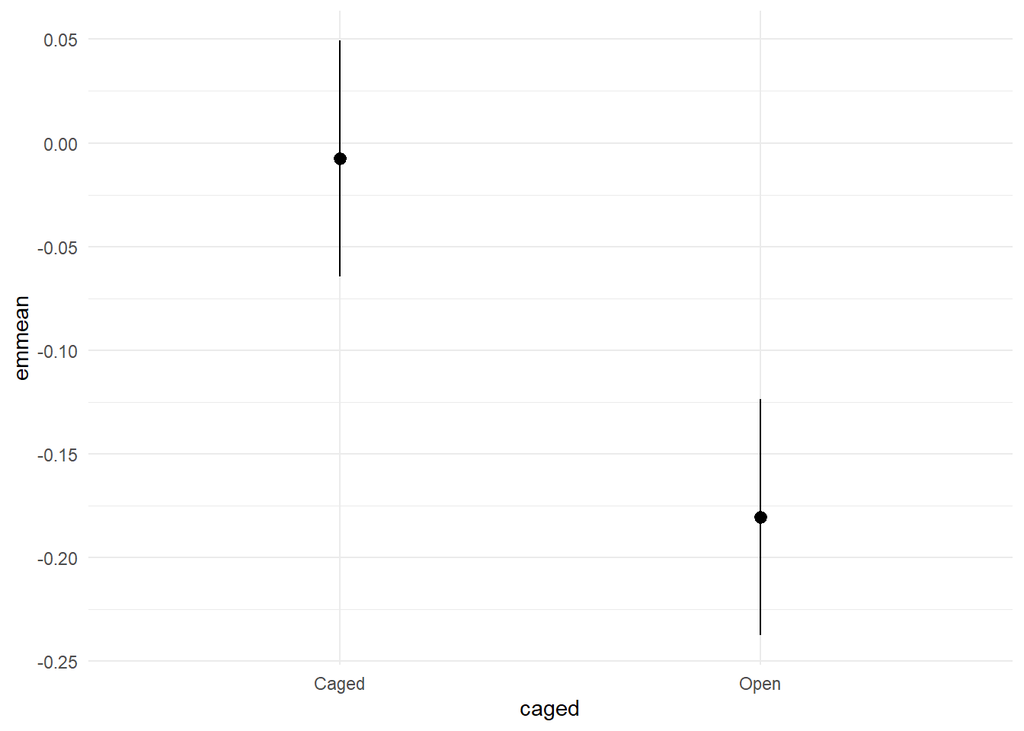

```
## NOTE: Results may be misleading due to involvement in interactions
```

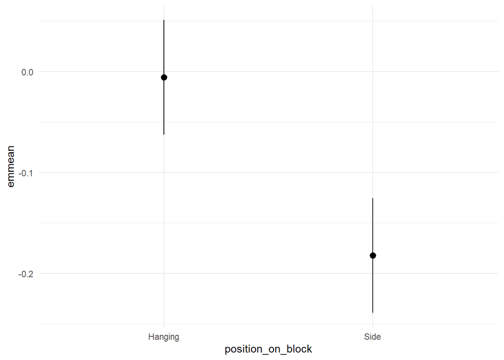

Difference in position has same diff in mean as caged. Impacts on the system are equal and connected for open vs caged. Both variables appear to be significant with alpha 0.08 on the systems and signif sub that alpha.

# 3.1

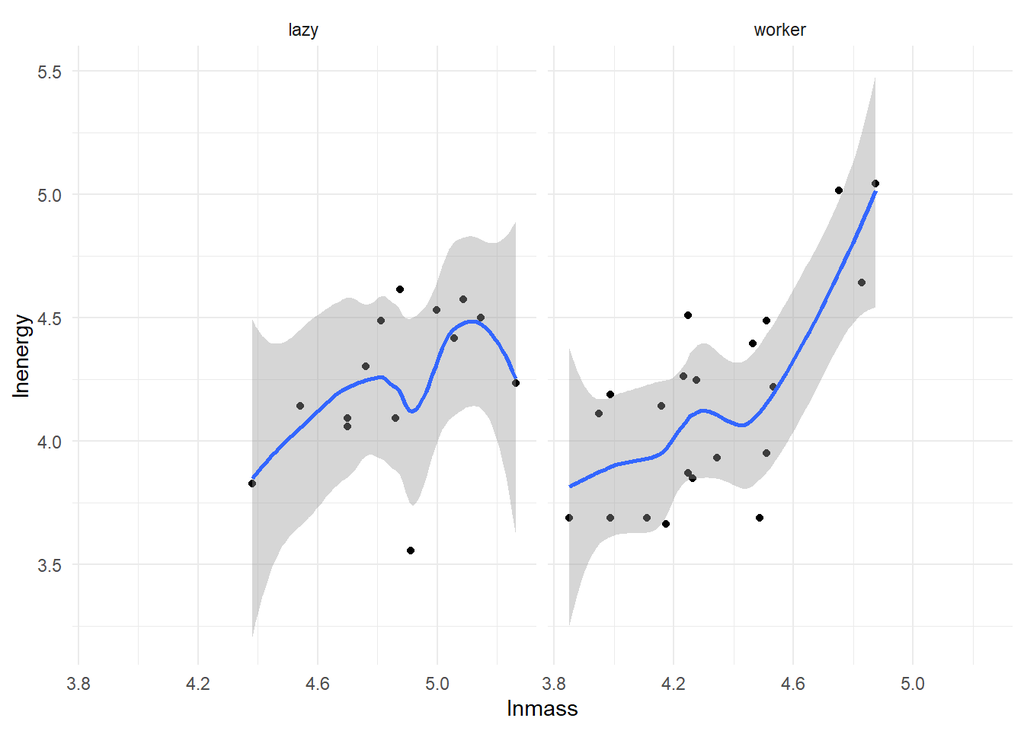

```
## Using 10 posterior samples for ppc type 'dens_overlay' by default.
```

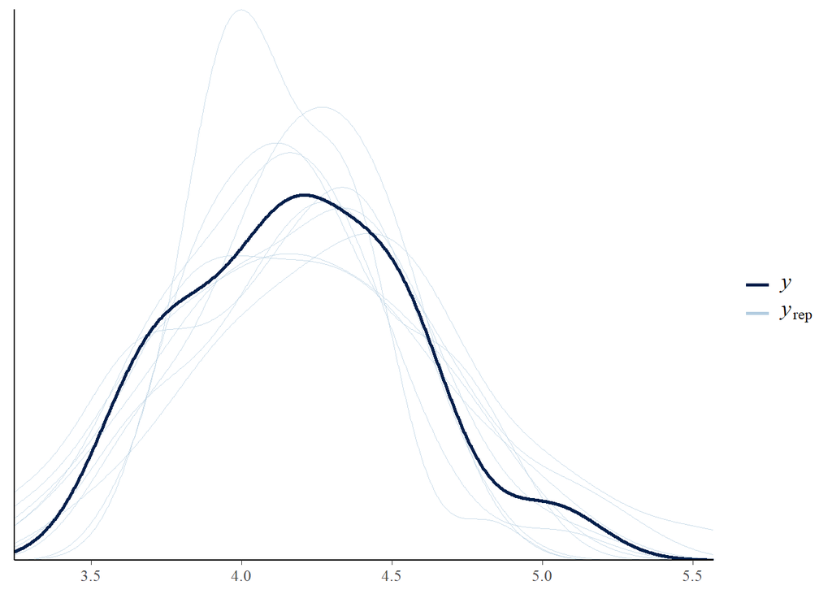

BRM pp_check looks like normal chains with somewhat of a normal curve. Data should meet assumptions.

# 3.2

```
## recompiling to avoid crashing R session
```

```
##          elpd_diff se_diff
## rat_brm   0.0       0.0
## rat_brm2 -0.8       0.7
```

First brm is better option for modeling, interaction model is messy. lnmass + caste > lnmass * caste.

# 3.3

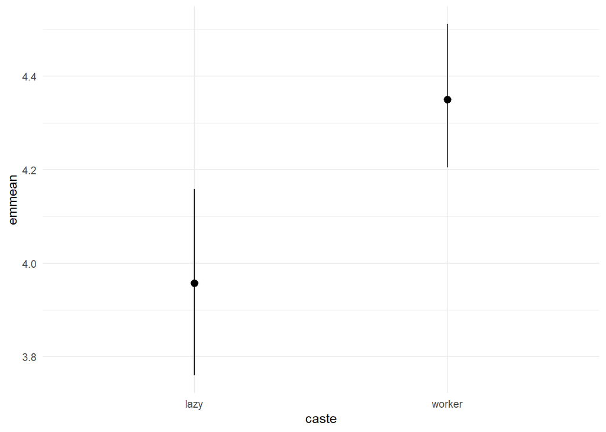

There is a clear difference in the means of lazy and worker. I would plot my model before discussing my conclusions further. I assume a more visually appealing plot will make it more clear.

# 3.4

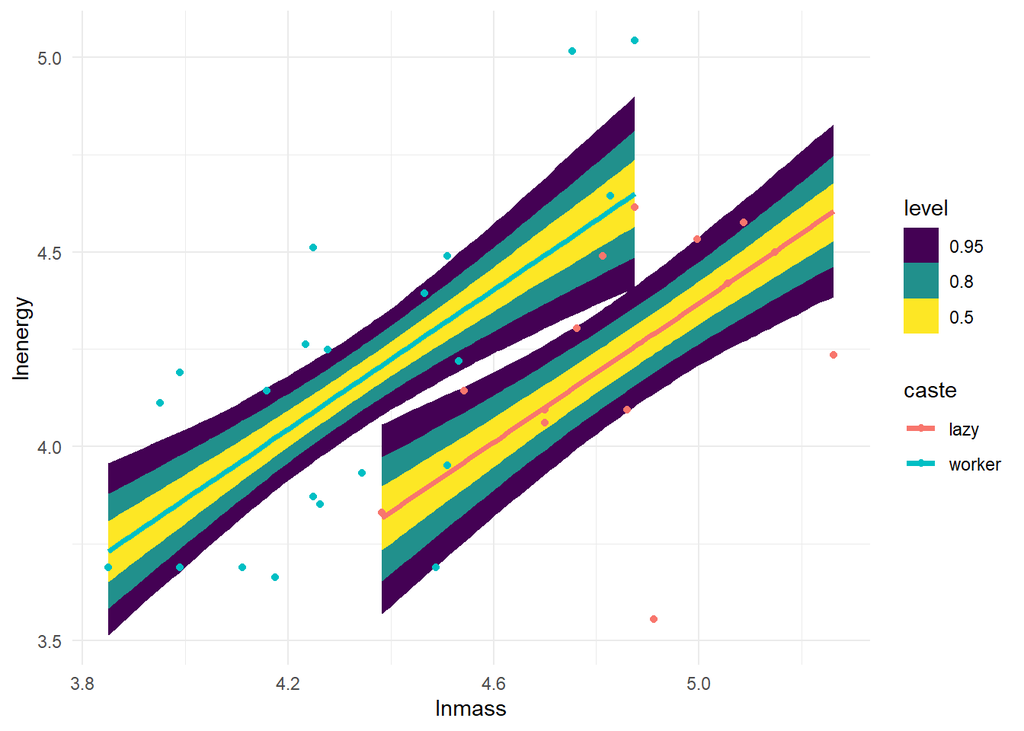